# Tweet Airline NLP Sentiment Analysis

# Testing Dataset

To measure unbiased out-of-sample error of models, we can test models on positive movie reviews, negative and toxic comments along with neutral sentences from Wikipedia, each with 10 samples.

```python
# from movie reviews dataset
positivesSource = pd.read_csv("MovieReviews.csv")
positives = positivesSource[positivesSource['sentiment']=='positive'].head(10)
# from toxic comments dataset
negativesSource = pd.read_csv("ToxicComments.csv")
negatives = negativesSource[(negativesSource['insult']==1) & (negativesSource['toxic']==0)].head(10)
# from wikipedia articles
neutrals = pd.DataFrame({"text":
                         ["The Constitution, originally comprising seven articles, delineates the national frame of government.",
                          "The process of selecting the delegates for the First and Second Continental Congresses underscores the revolutionary role of the people of the colonies in establishing a central governing body.",
                         "The first English use of the word 'data' is from the 1640s.",
                         "For example, the height of Mount Everest is generally considered data.",
                         "Others argue that data science is distinct from statistics because it focuses on problems and techniques unique to digital data.",
                         "The availability and interpretation of big data has altered the business models of old industries and enabled the creation of new ones.",
                         "Data mining is the process of applying these methods with the intention of uncovering hidden patterns in large datasets.",
                         "There is biological variation in the human species — with traits such as blood type, genetic diseases, cranial features, facial features.",
                         "Venus is a terrestrial planet and is sometimes called Earth's 'sister planet' because of their similar size, mass, proximity to the Sun, and bulk composition.",
                         "In 2008 and 2009, the first direct evidence for ongoing volcanism was observed by Venus Express."],
                         "sentiment":["neutral"]*10})
```

```python
positivesDf = pd.DataFrame({"text":positives["review"].values,
                           "sentiment":["positive"]*10})
negativesDf = pd.DataFrame({"text":negatives["comment_text"].values,
                           "sentiment":["negative"]*10})
testDf = shuffle(pd.concat([positivesDf,negativesDf,neutrals],ignore_index=True))
testDf = testDf.reset_index(drop=True)
testDf['numSentiment'] = testDf["sentiment"].apply(
                                lambda sentiment: 1 if sentiment == "negative"
                                else (2 if sentiment == "neutral" else 3))
testDf.head()
```

|  | text | sentiment | numSentiment |
| --- | --- | --- | --- |
| 0 | Hebrew Name of Lydia \nAppologies to Til Eulen... | negative | 1 |
| 1 | Issues with Knox \n\nKnox run things like Gala... | negative | 1 |
| 2 | The availability and interpretation of big dat... | neutral | 2 |
| 3 | "=Reliable sources===\nCheating:\n""Barry Bond... | negative | 1 |
| 4 | I thought this was a wonderful way to spend ti... | positive | 3 |

```python
cleanedText = testDf['text'].apply(lambda text: mineTweet(text))
```

```python
lengths = cleanedText.apply(lambda minedText: len(minedText))
cleanedText = cleanedText.apply(lambda text: ' '.join(text))
```

```python
displayVaderMetrics(cleanedText,testDf['sentiment'])
displayHuggingFaceMetrics(cleanedText,testDf['sentiment'])
```

```
Accuracies: [0.667, 1.0, 0.667, 0.333, 1.0, 1.0, 1.0, 0.333, 0.667, 1.0]
Mean Accuracy: 0.7666666666666667
F1 Scores: [0.556, 1.0, 0.556, 0.167, 1.0, 1.0, 1.0, 0.333, 0.556, 1.0]
Mean F1: 0.7166666666666666
Precisions: [0.5, 1.0, 0.5, 0.111, 1.0, 1.0, 1.0, 0.333, 0.5, 1.0]
Mean Precision: 0.6944444444444444
Recalls: [0.667, 1.0, 0.667, 0.333, 1.0, 1.0, 1.0, 0.333, 0.667, 1.0]
Mean Recall: 0.7666666666666667
```

```
Accuracies: [0.333, 0.667, 0.667, 0.333, 0.667, 0.667, 0.667, 0.667, 0.667, 0.333]
Mean Accuracy: 0.5666666666666667
F1 Scores: [0.167, 0.556, 0.556, 0.167, 0.556, 0.556, 0.556, 0.556, 0.556, 0.167]
Mean F1: 0.43888888888888883
Precisions: [0.111, 0.5, 0.5, 0.111, 0.5, 0.5, 0.5, 0.5, 0.5, 0.111]
Mean Precision: 0.38333333333333336
Recalls: [0.333, 0.667, 0.667, 0.333, 0.667, 0.667, 0.667, 0.667, 0.667, 0.333]
Mean Recall: 0.5666666666666667
```

```python
newMined = cv.fit_transform(list(cleanedText)).toarray()
newX = pd.concat([pd.DataFrame(data=newMined), lengths],axis=1)
newX = newX.rename(columns={"text":"textLength"})
```

```python
# we use complement naive bayes
prediction = xgbBoost.predict(newX)
```

```python
# xgboost predictions and evaluation - looking at f1 score.
print("Accuracy:",accuracy_score(testDf['numSentiment'],
                                    prediction))
print("F1 Score:",f1_score(testDf['numSentiment'],prediction, average="macro"))
print("Precision:",precision_score(testDf['numSentiment'],prediction,average='macro'))
print("Recall:",recall_score(testDf['numSentiment'],prediction, average='macro'))
```

```
Accuracy: 0.5333333333333333
F1 Score: 0.48657616892911
Precision: 0.5468253968253968
Recall: 0.5333333333333333
```

```
<sklearn.metrics._plot.confusion_matrix.ConfusionMatrixDisplay at 0x7fb35e139c18>
```

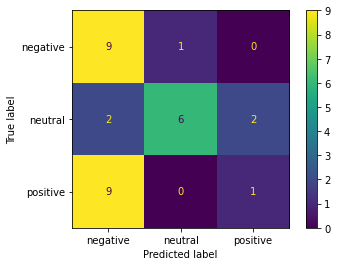

```python
plot_confusion_matrix(xgbBoost, newX, testDf['numSentiment'],display_labels=['negative','neutral','positive'])
```

```python
# keras model predictions and evaluation
testSeq = tokenizer.texts_to_sequences(cleanedText)
testSeq = pad_sequences(testSeq, maxlen=maxLength)
predictions = kerasExtraModel.predict_classes(testSeq)+1
print("Accuracy:", accuracy_score(testDf['numSentiment'],predictions))
print("F1 Score:", f1_score(testDf['numSentiment'],predictions,average='macro'))
print("Precision:", precision_score(testDf['numSentiment'],predictions,average='macro'))
print("Recall:",recall_score(testDf['numSentiment'],predictions,average='macro'))
```

```
Accuracy: 0.4
F1 Score: 0.3886087768440709
Precision: 0.43492063492063493
Recall: 0.4000000000000001
```

# Conclusions and Future Work

### Based on the evaluations, the model that seems to perform best from the 10-fold cross-validation scores are the naive bayes, keras word embedding neural network and xgboost (gradient boosted trees). However, it appears that the estimate of overfitting being between validation and training errors from the cross-validation didn't reflect the rise in error within the test dataset for the keras neural network (0.4 accuracy from overfitting effects). For this reason, the keras neural network could undergo structural changes to reduce overfitting with dropout layers among other options.

### For the test set, the pretrained vader classifier performed the best with the xgboost being second to it when comparing f1 score. The xgboost model has a relatively higher precision, which indicates less false positives. However, there seems to be more false negatives due to lower recall at 53.33%. One thing to note about benchmarks on pretrained models is that they are not being trained on the training set in the train/test splits in the 10-fold cross validation (CV). The main comparisons that make sense occur between the sklearn models that are trained on same 10-fold CV and evaluated.

### A problem with the data itself is that some tweets don't have information about whether they're from the same conversation or what they're replying to or if they're starting a new conversation. We could be missing crucial information. One example is the first row of the airlineSentiment dataframe: "@VirginAmerica What @dhepburn said." The issue with this tweet is that it could be neutral, but also either of the other two sentiments. We're not sure what @dhepburn said, so we can't assess the sentiment of the sentence exactly.

### For future work, we should focus on the data collection process that involves more extensive information on tweets such as a conversation number (so tweets in the same conversation are included). Also, we can look out for words that could be false positives - words that sound negative, but aren't.

### For intuitive models, sklearn library models may suffice. For better accuracy, we can consider long-short term memory neural networks and *transfer learning* or using different word embeddings.

### A popular area of research currently is sarcasm detection. Investigation into detecting sarcastic tendencies could be expanded on for potential improvement in out-of-sample error.